# Just Enough Statistics

Finn Catling & Ahmed Al-Hindawi

12 March 2018

# Before we start…

```r
library(readr)
library(dplyr)
library(ggplot2)
RCT <- read_csv("https://raw.githubusercontent.com/datascibc/Data-Science-for-Docs/master/data/breast-rct-clean-fakeage.csv")
```

# The big picture

Our RCT attempts to answer a research question by collecting data from a *sample* of a *population*.

Data collection consists in measuring the values of several *variables* for each member of the population.

# Descriptive statistics

- Inspect the data
- Organise the data
- Summarise the data

## Inferential statistics

- Draw conclusions about the population from the sample
- Test the reliability of those conclusions

## Variables

- Variables may be *continuous* or *discrete*
- Consider these:
  - **age**
  - **random**, **satisfaction**

# Distributions

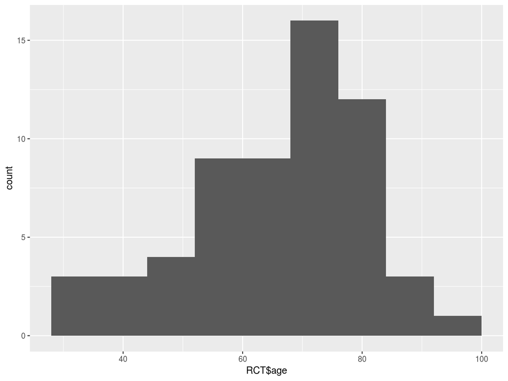

```r
RCT %>% ggplot(aes(x=RCT$age)) + geom_histogram(binwidth=8)
```

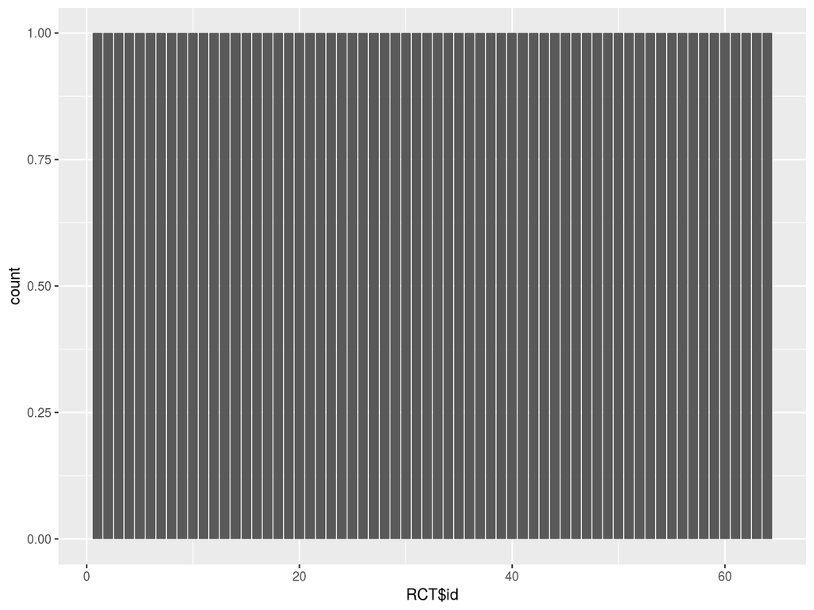

```r
RCT %>% ggplot(aes(x=RCT$id)) + geom_bar()
```

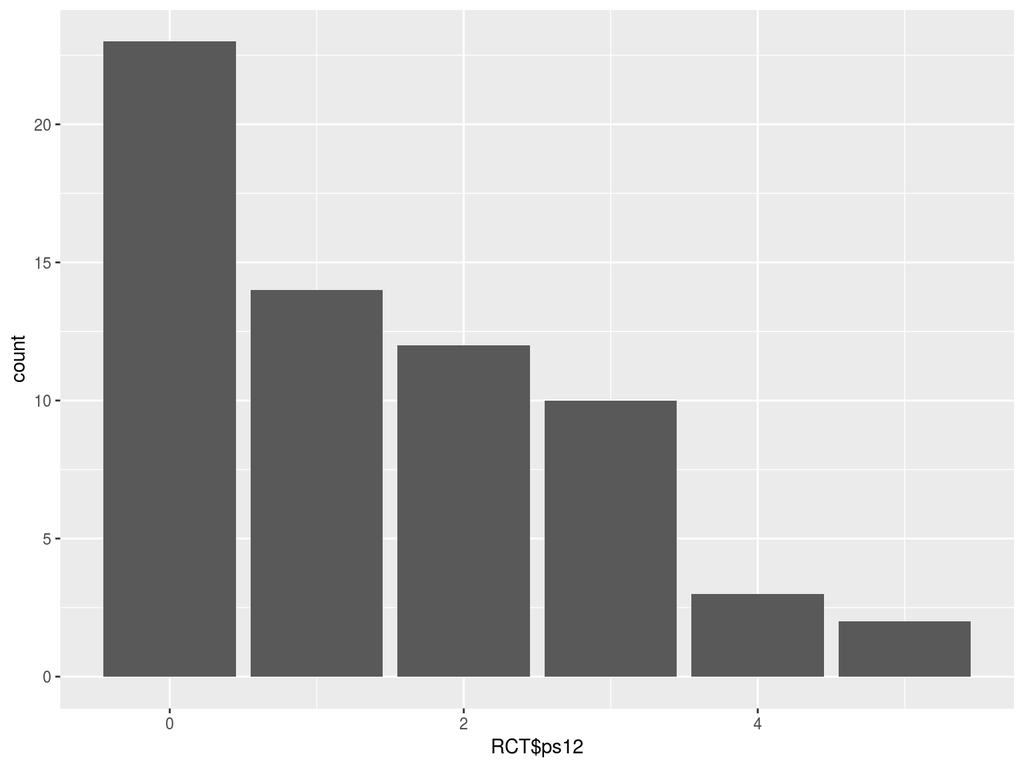

```r
RCT %>% ggplot(aes(x=RCT$ps12)) + geom_bar()
```

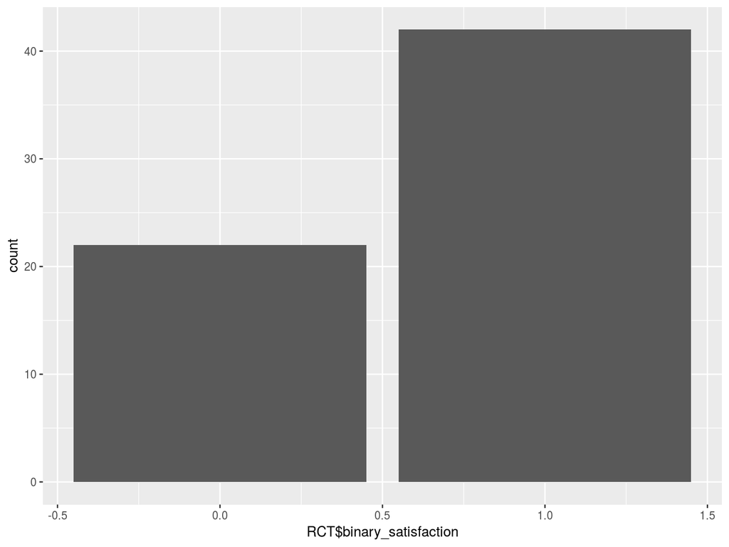

```r
RCT %>% ggplot(aes(x=RCT$binary_satisfaction)) + geom_bar()
```

Do our variables looks like this?

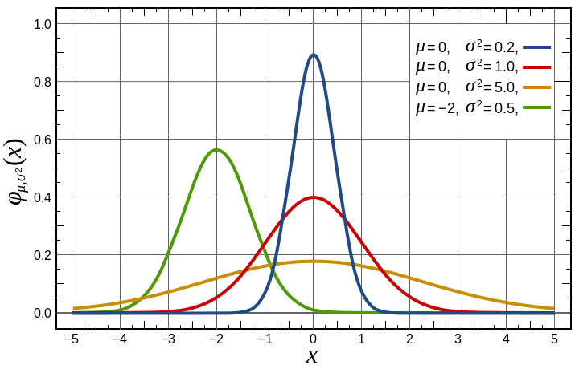

# Means, medians and modes

- Mean: sum of all datapoints / number of datapoints
- Median: middle datapoint
- Mode: most common datapoint

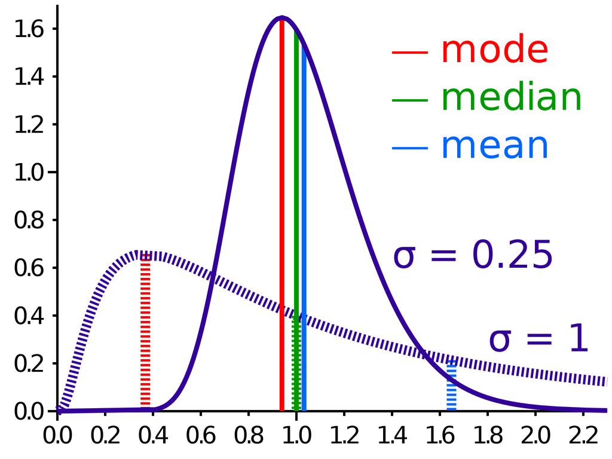

Have a go with these variables: **age**, **ps12**, **move24h**

You can use the functions `mean()` and `median()`, for example:

```r
mean(RCT$ps12, na.rm=TRUE)
```

```
## [1] 1.40625
```

```r
median(RCT$ps12, na.rm=TRUE)
```

```
## [1] 1
```

# Measuring ‘spread’

- For normally-distibuted data, use standard deviation
- For non normally-distributed data, use interquartile range

```r
IQR(RCT$age, na.rm=TRUE)
```

```
## [1] 22
```

```r
sd(RCT$age, na.rm=TRUE)
```

```
## [1] 14.55191
```

# Calculate it all at once

```r
summary(RCT)
```

```
##        X1              id          recruit               age
##  Min.   : 0.00   Min.   : 1.00   Length:64          Min.   :29.00
##  1st Qu.:15.75   1st Qu.:16.75   Class :character   1st Qu.:55.00
##  Median :31.50   Median :32.50   Mode  :character   Median :70.50
##  Mean   :31.50   Mean   :32.50                      Mean   :66.27
##  3rd Qu.:47.25   3rd Qu.:48.25                      3rd Qu.:77.00
##  Max.   :63.00   Max.   :64.00                      Max.   :95.00
##                                                     NA's   :4
##     gender             random               ps0h             ps3h
##  Length:64          Length:64          Min.   :0.0000   Min.   :0.000
##  Class :character   Class :character   1st Qu.:0.0000   1st Qu.:0.000
##  Mode  :character   Mode  :character   Median :0.0000   Median :1.000
##                                        Mean   :0.1905   Mean   :1.125
##                                        3rd Qu.:0.0000   3rd Qu.:2.000
##                                        Max.   :3.0000   Max.   :5.000
##                                        NA's   :1
##       ps12           ps24h          ps168h          move12h
##  Min.   :0.000   Min.   :0.00   Min.   :0.0000   Min.   :0.000
##  1st Qu.:0.000   1st Qu.:0.00   1st Qu.:0.0000   1st Qu.:0.000
##  Median :1.000   Median :1.00   Median :0.0000   Median :1.000
##  Mean   :1.406   Mean   :1.25   Mean   :0.6275   Mean   :1.078
##  3rd Qu.:2.000   3rd Qu.:2.00   3rd Qu.:1.0000   3rd Qu.:2.000
##  Max.   :5.000   Max.   :5.00   Max.   :3.0000   Max.   :5.000
##                                 NA's   :13
##     move24h          move168h        tylenol            codeine
##  Min.   :0.0000   Min.   :0.0000   Length:64          Length:64
##  1st Qu.:0.0000   1st Qu.:0.0000   Class :character   Class :character
##  Median :1.0000   Median :0.0000   Mode  :character   Mode  :character
##  Mean   :0.9375   Mean   :0.6078
##  3rd Qu.:1.2500   3rd Qu.:1.0000
##  Max.   :5.0000   Max.   :4.0000
##                   NA's   :13
##    oramorph            other                los          los_reason
##  Length:64          Length:64          Min.   : 0.000   Length:64
##  Class :character   Class :character   1st Qu.: 2.000   Class :character
##  Mode  :character   Mode  :character   Median : 3.000   Mode  :character
##                                        Mean   : 3.431
##                                        3rd Qu.: 4.000
##                                        Max.   :10.000
##                                        NA's   :13
##  satisfaction          fake_age     binary_satisfaction
##  Length:64          Min.   :43.98   Min.   :0.0000
##  Class :character   1st Qu.:63.13   1st Qu.:0.0000
##  Mode  :character   Median :76.99   Median :1.0000
##                     Mean   :73.49   Mean   :0.6562
##                     3rd Qu.:83.01   3rd Qu.:1.0000
##                     Max.   :92.50   Max.   :1.0000
##
```

# Testing (here be dragons)

- best_option <- “**Ask a statistician**”
- pragmatic_option <- “Do it yourself, **carefully** and **simply**”

## Think about

1. The hypothesis you want to test
2. Where your observations come from
3. The type of variables you are dealing with
4. The assumptions that different tests use
5. Interpreting the test results

# Hypothesis 1

> ‘Mean age differs between the two treatment arms’

> Recall: The treatment arms are 1) patients receiving local anaesthetic via drain, and 2) patients receiving local anaesthetic via injection to the skin flaps’
- What sort of variables are these?
- What is the *independent variable*?
- What is the *dependent variable*?
- What is the *null hypothesis*?
- **Which test should we use?**

# Unpaired 2-tail t test: Assumptions

- Values within each group are independent
- The two groups are independent of one another
- (Values in each group should be approximately normally-distributed)

# Let’s look at our data…

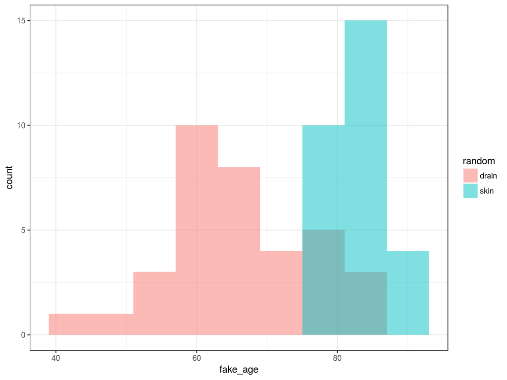

```r
RCT %>% ggplot(aes(x=fake_age, group=random, fill=random)) + geom_histogram(position="identity", alpha=0.5, binwidth=6) + theme_bw()
```

Note that the ‘spread’ of the groups is different - a problem for the standard t test, but R takes care of this for us behind the scenes.

# Let’s run the test!

```r
t.test(RCT$fake_age~RCT$random)
```

```
##
##  Welch Two Sample t-test
##
## data:  RCT$fake_age by RCT$random
## t = -9.6394, df = 48.021, p-value = 8.275e-13
## alternative hypothesis: true difference in means is not equal to 0
## 95 percent confidence interval:
##  -21.19970 -13.88222
## sample estimates:
## mean in group drain  mean in group skin
##            65.54566            83.08662
```

# Hypothesis 2

> ‘Patient satisfaction after axillary node dissection depends on treatment arm.’

# Hypothesis 2

> ‘Patient satisfaction after axillary node dissection depends on treatment arm.’
- What sort of variables are these?
- What is the *independent variable*?
- What is the *dependent variable*?
- What is the *null hypothesis*?
- **Which test should we use?**

# Chi-squared test for independence: Assumptions

- The two groups are independent of one another
- Count in each cell of the table should be 5 or more

# Let’s look at our data

```r
tbl = table(RCT$random, RCT$binary_satisfaction)
```

[output not shown]

## Let’s run the test!

```r
chisq.test(tbl)
```

```
##
##  Pearson's Chi-squared test with Yates' continuity correction
##
## data:  tbl
## X-squared = 3.4854, df = 1, p-value = 0.06191
```

# Picking the right test

[UCLA Which test?](https://stats.idre.ucla.edu/other/mult-pkg/whatstat/)

# A gentle (and pretty!) intro to probability/stats

[Seeing theory](http://students.brown.edu/seeing-theory/)